# Risk Factor Analysis

## Outcome Variable

**Outcome Variable:** ever_stunted

## Predictor Variables

**Intervention Variable:** enstunt

**Adjustment Set:**

unadjusted

## Stratifying Variables

The analysis was stratified on these variable(s):

- agecat
- studyid
- country

## Data Summary

| agecat | studyid | country | A | n | nA | nAY0 | nAY1 |
| --- | --- | --- | --- | --- | --- | --- | --- |
| 3 months | ki0047075b-MAL-ED | BANGLADESH | 0 | 257 | 210 | 182 | 28 |
| 3 months | ki0047075b-MAL-ED | BANGLADESH | 1 | 257 | 47 | 0 | 47 |
| 3 months | ki0047075b-MAL-ED | BRAZIL | 0 | 191 | 170 | 157 | 13 |
| 3 months | ki0047075b-MAL-ED | BRAZIL | 1 | 191 | 21 | 0 | 21 |
| 3 months | ki0047075b-MAL-ED | INDIA | 0 | 206 | 173 | 150 | 23 |
| 3 months | ki0047075b-MAL-ED | INDIA | 1 | 206 | 33 | 0 | 33 |
| 3 months | ki0047075b-MAL-ED | NEPAL | 0 | 173 | 155 | 147 | 8 |
| 3 months | ki0047075b-MAL-ED | NEPAL | 1 | 173 | 18 | 0 | 18 |
| 3 months | ki0047075b-MAL-ED | PERU | 0 | 287 | 253 | 192 | 61 |
| 3 months | ki0047075b-MAL-ED | PERU | 1 | 287 | 34 | 0 | 34 |
| 3 months | ki0047075b-MAL-ED | SOUTH AFRICA | 0 | 262 | 234 | 193 | 41 |
| 3 months | ki0047075b-MAL-ED | SOUTH AFRICA | 1 | 262 | 28 | 0 | 28 |
| 3 months | ki0047075b-MAL-ED | TANZANIA, UNITED REPUBLIC OF | 0 | 123 | 105 | 91 | 14 |
| 3 months | ki0047075b-MAL-ED | TANZANIA, UNITED REPUBLIC OF | 1 | 123 | 18 | 0 | 18 |
| 3 months | ki1000108-CMC-V-BCS-2002 | INDIA | 0 | 97 | 81 | 56 | 25 |
| 3 months | ki1000108-CMC-V-BCS-2002 | INDIA | 1 | 97 | 16 | 0 | 16 |
| 3 months | ki1000108-IRC | INDIA | 0 | 410 | 362 | 278 | 84 |
| 3 months | ki1000108-IRC | INDIA | 1 | 410 | 48 | 2 | 46 |
| 3 months | ki1000109-EE | PAKISTAN | 0 | 9 | 6 | 4 | 2 |
| 3 months | ki1000109-EE | PAKISTAN | 1 | 9 | 3 | 0 | 3 |
| 3 months | ki1000109-ResPak | PAKISTAN | 0 | 91 | 70 | 40 | 30 |
| 3 months | ki1000109-ResPak | PAKISTAN | 1 | 91 | 21 | 0 | 21 |
| 3 months | ki1000304b-SAS-CompFeed | INDIA | 0 | 469 | 339 | 313 | 26 |
| 3 months | ki1000304b-SAS-CompFeed | INDIA | 1 | 469 | 130 | 0 | 130 |
| 3 months | ki1017093-NIH-Birth | BANGLADESH | 0 | 624 | 525 | 484 | 41 |
| 3 months | ki1017093-NIH-Birth | BANGLADESH | 1 | 624 | 99 | 0 | 99 |
| 3 months | ki1017093c-NIH-Crypto | BANGLADESH | 0 | 27 | 22 | 21 | 1 |
| 3 months | ki1017093c-NIH-Crypto | BANGLADESH | 1 | 27 | 5 | 0 | 5 |
| 3 months | ki1066203-TanzaniaChild2 | TANZANIA, UNITED REPUBLIC OF | 0 | 20 | 19 | 16 | 3 |
| 3 months | ki1066203-TanzaniaChild2 | TANZANIA, UNITED REPUBLIC OF | 1 | 20 | 1 | 0 | 1 |

[output cut: 272 more lines]

The following strata were considered:

- agecat: 12 months, studyid: ki0047075b-MAL-ED, country: BANGLADESH
- agecat: 12 months, studyid: ki0047075b-MAL-ED, country: BRAZIL
- agecat: 12 months, studyid: ki0047075b-MAL-ED, country: INDIA
- agecat: 12 months, studyid: ki0047075b-MAL-ED, country: NEPAL
- agecat: 12 months, studyid: ki0047075b-MAL-ED, country: PERU
- agecat: 12 months, studyid: ki0047075b-MAL-ED, country: SOUTH AFRICA
- agecat: 12 months, studyid: ki0047075b-MAL-ED, country: TANZANIA, UNITED REPUBLIC OF
- agecat: 12 months, studyid: ki1000108-CMC-V-BCS-2002, country: INDIA
- agecat: 12 months, studyid: ki1000108-IRC, country: INDIA
- agecat: 12 months, studyid: ki1000109-EE, country: PAKISTAN
- agecat: 12 months, studyid: ki1000109-ResPak, country: PAKISTAN
- agecat: 12 months, studyid: ki1000304b-SAS-CompFeed, country: INDIA
- agecat: 12 months, studyid: ki1000304b-SAS-FoodSuppl, country: INDIA
- agecat: 12 months, studyid: ki1017093-NIH-Birth, country: BANGLADESH
- agecat: 12 months, studyid: ki1017093c-NIH-Crypto, country: BANGLADESH
- agecat: 12 months, studyid: ki1066203-TanzaniaChild2, country: TANZANIA, UNITED REPUBLIC OF
- agecat: 12 months, studyid: ki1101329-Keneba, country: GAMBIA
- agecat: 12 months, studyid: ki1112895-Guatemala BSC, country: GUATEMALA
- agecat: 12 months, studyid: ki1112895-iLiNS-Zinc, country: BURKINA FASO
- agecat: 12 months, studyid: ki1113344-GMS-Nepal, country: NEPAL
- agecat: 12 months, studyid: ki1114097-CMIN, country: BRAZIL
- agecat: 12 months, studyid: ki1114097-CMIN, country: GUINEA-BISSAU
- agecat: 12 months, studyid: ki1114097-CMIN, country: PERU
- agecat: 12 months, studyid: ki1114097-CONTENT, country: PERU
- agecat: 12 months, studyid: ki1119695-PROBIT, country: BELARUS
- agecat: 12 months, studyid: ki1126311-ZVITAMBO, country: ZIMBABWE
- agecat: 12 months, studyid: ki1135781-COHORTS, country: GUATEMALA
- agecat: 12 months, studyid: ki1135781-COHORTS, country: INDIA
- agecat: 12 months, studyid: ki1135781-COHORTS, country: PHILIPPINES
- agecat: 12 months, studyid: ki1148112-LCNI-5, country: MALAWI
- agecat: 12 months, studyid: kiGH5241-JiVitA-3, country: BANGLADESH
- agecat: 12 months, studyid: kiGH5241-JiVitA-4, country: BANGLADESH
- agecat: 18 months, studyid: ki0047075b-MAL-ED, country: BANGLADESH
- agecat: 18 months, studyid: ki0047075b-MAL-ED, country: BRAZIL
- agecat: 18 months, studyid: ki0047075b-MAL-ED, country: INDIA
- agecat: 18 months, studyid: ki0047075b-MAL-ED, country: NEPAL
- agecat: 18 months, studyid: ki0047075b-MAL-ED, country: PERU
- agecat: 18 months, studyid: ki0047075b-MAL-ED, country: SOUTH AFRICA
- agecat: 18 months, studyid: ki0047075b-MAL-ED, country: TANZANIA, UNITED REPUBLIC OF
- agecat: 18 months, studyid: ki1000108-CMC-V-BCS-2002, country: INDIA
- agecat: 18 months, studyid: ki1000108-IRC, country: INDIA
- agecat: 18 months, studyid: ki1000109-EE, country: PAKISTAN
- agecat: 18 months, studyid: ki1000109-ResPak, country: PAKISTAN
- agecat: 18 months, studyid: ki1000304b-SAS-CompFeed, country: INDIA
- agecat: 18 months, studyid: ki1000304b-SAS-FoodSuppl, country: INDIA
- agecat: 18 months, studyid: ki1017093-NIH-Birth, country: BANGLADESH
- agecat: 18 months, studyid: ki1017093c-NIH-Crypto, country: BANGLADESH
- agecat: 18 months, studyid: ki1066203-TanzaniaChild2, country: TANZANIA, UNITED REPUBLIC OF
- agecat: 18 months, studyid: ki1101329-Keneba, country: GAMBIA
- agecat: 18 months, studyid: ki1112895-Guatemala BSC, country: GUATEMALA
- agecat: 18 months, studyid: ki1112895-iLiNS-Zinc, country: BURKINA FASO
- agecat: 18 months, studyid: ki1113344-GMS-Nepal, country: NEPAL
- agecat: 18 months, studyid: ki1114097-CMIN, country: BRAZIL
- agecat: 18 months, studyid: ki1114097-CMIN, country: GUINEA-BISSAU
- agecat: 18 months, studyid: ki1114097-CMIN, country: PERU
- agecat: 18 months, studyid: ki1114097-CONTENT, country: PERU
- agecat: 18 months, studyid: ki1119695-PROBIT, country: BELARUS
- agecat: 18 months, studyid: ki1126311-ZVITAMBO, country: ZIMBABWE
- agecat: 18 months, studyid: ki1135781-COHORTS, country: GUATEMALA
- agecat: 18 months, studyid: ki1135781-COHORTS, country: PHILIPPINES
- agecat: 18 months, studyid: ki1148112-LCNI-5, country: MALAWI
- agecat: 18 months, studyid: kiGH5241-JiVitA-3, country: BANGLADESH
- agecat: 18 months, studyid: kiGH5241-JiVitA-4, country: BANGLADESH
- agecat: 24 months, studyid: ki0047075b-MAL-ED, country: BANGLADESH
- agecat: 24 months, studyid: ki0047075b-MAL-ED, country: BRAZIL
- agecat: 24 months, studyid: ki0047075b-MAL-ED, country: INDIA
- agecat: 24 months, studyid: ki0047075b-MAL-ED, country: NEPAL
- agecat: 24 months, studyid: ki0047075b-MAL-ED, country: PERU
- agecat: 24 months, studyid: ki0047075b-MAL-ED, country: SOUTH AFRICA
- agecat: 24 months, studyid: ki0047075b-MAL-ED, country: TANZANIA, UNITED REPUBLIC OF
- agecat: 24 months, studyid: ki1000108-CMC-V-BCS-2002, country: INDIA
- agecat: 24 months, studyid: ki1000108-IRC, country: INDIA
- agecat: 24 months, studyid: ki1000109-EE, country: PAKISTAN
- agecat: 24 months, studyid: ki1000304b-SAS-CompFeed, country: INDIA
- agecat: 24 months, studyid: ki1000304b-SAS-FoodSuppl, country: INDIA
- agecat: 24 months, studyid: ki1017093-NIH-Birth, country: BANGLADESH
- agecat: 24 months, studyid: ki1017093c-NIH-Crypto, country: BANGLADESH
- agecat: 24 months, studyid: ki1066203-TanzaniaChild2, country: TANZANIA, UNITED REPUBLIC OF
- agecat: 24 months, studyid: ki1101329-Keneba, country: GAMBIA
- agecat: 24 months, studyid: ki1112895-iLiNS-Zinc, country: BURKINA FASO
- agecat: 24 months, studyid: ki1113344-GMS-Nepal, country: NEPAL
- agecat: 24 months, studyid: ki1114097-CMIN, country: BRAZIL
- agecat: 24 months, studyid: ki1114097-CMIN, country: GUINEA-BISSAU
- agecat: 24 months, studyid: ki1114097-CMIN, country: PERU
- agecat: 24 months, studyid: ki1114097-CONTENT, country: PERU
- agecat: 24 months, studyid: ki1119695-PROBIT, country: BELARUS
- agecat: 24 months, studyid: ki1126311-ZVITAMBO, country: ZIMBABWE
- agecat: 24 months, studyid: ki1135781-COHORTS, country: GUATEMALA
- agecat: 24 months, studyid: ki1135781-COHORTS, country: PHILIPPINES
- agecat: 24 months, studyid: ki1148112-LCNI-5, country: MALAWI
- agecat: 24 months, studyid: kiGH5241-JiVitA-3, country: BANGLADESH
- agecat: 24 months, studyid: kiGH5241-JiVitA-4, country: BANGLADESH
- agecat: 3 months, studyid: ki0047075b-MAL-ED, country: BANGLADESH
- agecat: 3 months, studyid: ki0047075b-MAL-ED, country: BRAZIL
- agecat: 3 months, studyid: ki0047075b-MAL-ED, country: INDIA
- agecat: 3 months, studyid: ki0047075b-MAL-ED, country: NEPAL
- agecat: 3 months, studyid: ki0047075b-MAL-ED, country: PERU
- agecat: 3 months, studyid: ki0047075b-MAL-ED, country: SOUTH AFRICA
- agecat: 3 months, studyid: ki0047075b-MAL-ED, country: TANZANIA, UNITED REPUBLIC OF
- agecat: 3 months, studyid: ki1000108-CMC-V-BCS-2002, country: INDIA
- agecat: 3 months, studyid: ki1000108-IRC, country: INDIA
- agecat: 3 months, studyid: ki1000109-EE, country: PAKISTAN
- agecat: 3 months, studyid: ki1000109-ResPak, country: PAKISTAN
- agecat: 3 months, studyid: ki1000304b-SAS-CompFeed, country: INDIA
- agecat: 3 months, studyid: ki1017093-NIH-Birth, country: BANGLADESH
- agecat: 3 months, studyid: ki1017093c-NIH-Crypto, country: BANGLADESH
- agecat: 3 months, studyid: ki1066203-TanzaniaChild2, country: TANZANIA, UNITED REPUBLIC OF
- agecat: 3 months, studyid: ki1101329-Keneba, country: GAMBIA
- agecat: 3 months, studyid: ki1113344-GMS-Nepal, country: NEPAL
- agecat: 3 months, studyid: ki1114097-CMIN, country: BANGLADESH
- agecat: 3 months, studyid: ki1114097-CMIN, country: BRAZIL
- agecat: 3 months, studyid: ki1114097-CMIN, country: GUINEA-BISSAU
- agecat: 3 months, studyid: ki1114097-CMIN, country: PERU
- agecat: 3 months, studyid: ki1114097-CONTENT, country: PERU
- agecat: 3 months, studyid: ki1119695-PROBIT, country: BELARUS
- agecat: 3 months, studyid: ki1126311-ZVITAMBO, country: ZIMBABWE
- agecat: 3 months, studyid: ki1135781-COHORTS, country: GUATEMALA
- agecat: 3 months, studyid: ki1135781-COHORTS, country: INDIA
- agecat: 3 months, studyid: ki1135781-COHORTS, country: PHILIPPINES
- agecat: 3 months, studyid: kiGH5241-JiVitA-3, country: BANGLADESH
- agecat: 3 months, studyid: kiGH5241-JiVitA-4, country: BANGLADESH
- agecat: 6 months, studyid: ki0047075b-MAL-ED, country: BANGLADESH
- agecat: 6 months, studyid: ki0047075b-MAL-ED, country: BRAZIL
- agecat: 6 months, studyid: ki0047075b-MAL-ED, country: INDIA
- agecat: 6 months, studyid: ki0047075b-MAL-ED, country: NEPAL
- agecat: 6 months, studyid: ki0047075b-MAL-ED, country: PERU
- agecat: 6 months, studyid: ki0047075b-MAL-ED, country: SOUTH AFRICA
- agecat: 6 months, studyid: ki0047075b-MAL-ED, country: TANZANIA, UNITED REPUBLIC OF
- agecat: 6 months, studyid: ki1000108-CMC-V-BCS-2002, country: INDIA
- agecat: 6 months, studyid: ki1000108-IRC, country: INDIA
- agecat: 6 months, studyid: ki1000109-EE, country: PAKISTAN
- agecat: 6 months, studyid: ki1000109-ResPak, country: PAKISTAN
- agecat: 6 months, studyid: ki1000304b-SAS-CompFeed, country: INDIA
- agecat: 6 months, studyid: ki1000304b-SAS-FoodSuppl, country: INDIA
- agecat: 6 months, studyid: ki1017093-NIH-Birth, country: BANGLADESH
- agecat: 6 months, studyid: ki1017093c-NIH-Crypto, country: BANGLADESH
- agecat: 6 months, studyid: ki1066203-TanzaniaChild2, country: TANZANIA, UNITED REPUBLIC OF
- agecat: 6 months, studyid: ki1101329-Keneba, country: GAMBIA
- agecat: 6 months, studyid: ki1112895-Guatemala BSC, country: GUATEMALA
- agecat: 6 months, studyid: ki1113344-GMS-Nepal, country: NEPAL
- agecat: 6 months, studyid: ki1114097-CMIN, country: BRAZIL
- agecat: 6 months, studyid: ki1114097-CMIN, country: GUINEA-BISSAU
- agecat: 6 months, studyid: ki1114097-CMIN, country: PERU
- agecat: 6 months, studyid: ki1114097-CONTENT, country: PERU
- agecat: 6 months, studyid: ki1119695-PROBIT, country: BELARUS
- agecat: 6 months, studyid: ki1126311-ZVITAMBO, country: ZIMBABWE
- agecat: 6 months, studyid: ki1135781-COHORTS, country: GUATEMALA
- agecat: 6 months, studyid: ki1135781-COHORTS, country: PHILIPPINES
- agecat: 6 months, studyid: ki1148112-LCNI-5, country: MALAWI
- agecat: 6 months, studyid: kiGH5241-JiVitA-3, country: BANGLADESH
- agecat: 6 months, studyid: kiGH5241-JiVitA-4, country: BANGLADESH

### Dropped Strata

Some strata were dropped due to rare outcomes:

- agecat: 3 months, studyid: ki0047075b-MAL-ED, country: BANGLADESH
- agecat: 3 months, studyid: ki0047075b-MAL-ED, country: BRAZIL
- agecat: 3 months, studyid: ki0047075b-MAL-ED, country: INDIA
- agecat: 3 months, studyid: ki0047075b-MAL-ED, country: NEPAL
- agecat: 3 months, studyid: ki0047075b-MAL-ED, country: PERU
- agecat: 3 months, studyid: ki0047075b-MAL-ED, country: SOUTH AFRICA
- agecat: 3 months, studyid: ki0047075b-MAL-ED, country: TANZANIA, UNITED REPUBLIC OF
- agecat: 3 months, studyid: ki1000108-CMC-V-BCS-2002, country: INDIA
- agecat: 3 months, studyid: ki1000108-IRC, country: INDIA
- agecat: 3 months, studyid: ki1000109-EE, country: PAKISTAN
- agecat: 3 months, studyid: ki1000109-ResPak, country: PAKISTAN
- agecat: 3 months, studyid: ki1000304b-SAS-CompFeed, country: INDIA
- agecat: 3 months, studyid: ki1017093-NIH-Birth, country: BANGLADESH
- agecat: 3 months, studyid: ki1017093c-NIH-Crypto, country: BANGLADESH
- agecat: 3 months, studyid: ki1066203-TanzaniaChild2, country: TANZANIA, UNITED REPUBLIC OF
- agecat: 3 months, studyid: ki1113344-GMS-Nepal, country: NEPAL
- agecat: 3 months, studyid: ki1114097-CMIN, country: BANGLADESH
- agecat: 3 months, studyid: ki1114097-CMIN, country: BRAZIL
- agecat: 3 months, studyid: ki1114097-CMIN, country: GUINEA-BISSAU
- agecat: 3 months, studyid: ki1114097-CMIN, country: PERU
- agecat: 3 months, studyid: ki1114097-CONTENT, country: PERU
- agecat: 3 months, studyid: ki1119695-PROBIT, country: BELARUS
- agecat: 3 months, studyid: ki1135781-COHORTS, country: GUATEMALA
- agecat: 3 months, studyid: ki1135781-COHORTS, country: INDIA
- agecat: 3 months, studyid: ki1135781-COHORTS, country: PHILIPPINES
- agecat: 3 months, studyid: kiGH5241-JiVitA-3, country: BANGLADESH
- agecat: 3 months, studyid: kiGH5241-JiVitA-4, country: BANGLADESH
- agecat: 6 months, studyid: ki0047075b-MAL-ED, country: BANGLADESH
- agecat: 6 months, studyid: ki0047075b-MAL-ED, country: BRAZIL
- agecat: 6 months, studyid: ki0047075b-MAL-ED, country: INDIA
- agecat: 6 months, studyid: ki0047075b-MAL-ED, country: NEPAL
- agecat: 6 months, studyid: ki0047075b-MAL-ED, country: PERU
- agecat: 6 months, studyid: ki0047075b-MAL-ED, country: SOUTH AFRICA
- agecat: 6 months, studyid: ki0047075b-MAL-ED, country: TANZANIA, UNITED REPUBLIC OF
- agecat: 6 months, studyid: ki1000108-CMC-V-BCS-2002, country: INDIA
- agecat: 6 months, studyid: ki1000108-IRC, country: INDIA
- agecat: 6 months, studyid: ki1000109-EE, country: PAKISTAN
- agecat: 6 months, studyid: ki1000109-ResPak, country: PAKISTAN
- agecat: 6 months, studyid: ki1000304b-SAS-CompFeed, country: INDIA
- agecat: 6 months, studyid: ki1000304b-SAS-FoodSuppl, country: INDIA
- agecat: 6 months, studyid: ki1017093-NIH-Birth, country: BANGLADESH
- agecat: 6 months, studyid: ki1017093c-NIH-Crypto, country: BANGLADESH
- agecat: 6 months, studyid: ki1066203-TanzaniaChild2, country: TANZANIA, UNITED REPUBLIC OF
- agecat: 6 months, studyid: ki1112895-Guatemala BSC, country: GUATEMALA
- agecat: 6 months, studyid: ki1113344-GMS-Nepal, country: NEPAL
- agecat: 6 months, studyid: ki1114097-CMIN, country: BRAZIL
- agecat: 6 months, studyid: ki1114097-CMIN, country: GUINEA-BISSAU
- agecat: 6 months, studyid: ki1114097-CMIN, country: PERU
- agecat: 6 months, studyid: ki1114097-CONTENT, country: PERU
- agecat: 6 months, studyid: ki1119695-PROBIT, country: BELARUS
- agecat: 6 months, studyid: ki1135781-COHORTS, country: GUATEMALA
- agecat: 6 months, studyid: ki1135781-COHORTS, country: PHILIPPINES
- agecat: 6 months, studyid: ki1148112-LCNI-5, country: MALAWI
- agecat: 6 months, studyid: kiGH5241-JiVitA-3, country: BANGLADESH
- agecat: 6 months, studyid: kiGH5241-JiVitA-4, country: BANGLADESH
- agecat: 12 months, studyid: ki0047075b-MAL-ED, country: BANGLADESH
- agecat: 12 months, studyid: ki0047075b-MAL-ED, country: BRAZIL
- agecat: 12 months, studyid: ki0047075b-MAL-ED, country: INDIA
- agecat: 12 months, studyid: ki0047075b-MAL-ED, country: NEPAL
- agecat: 12 months, studyid: ki0047075b-MAL-ED, country: PERU
- agecat: 12 months, studyid: ki0047075b-MAL-ED, country: SOUTH AFRICA
- agecat: 12 months, studyid: ki0047075b-MAL-ED, country: TANZANIA, UNITED REPUBLIC OF
- agecat: 12 months, studyid: ki1000108-CMC-V-BCS-2002, country: INDIA
- agecat: 12 months, studyid: ki1000108-IRC, country: INDIA
- agecat: 12 months, studyid: ki1000109-EE, country: PAKISTAN
- agecat: 12 months, studyid: ki1000109-ResPak, country: PAKISTAN
- agecat: 12 months, studyid: ki1000304b-SAS-CompFeed, country: INDIA
- agecat: 12 months, studyid: ki1000304b-SAS-FoodSuppl, country: INDIA
- agecat: 12 months, studyid: ki1017093-NIH-Birth, country: BANGLADESH
- agecat: 12 months, studyid: ki1017093c-NIH-Crypto, country: BANGLADESH
- agecat: 12 months, studyid: ki1066203-TanzaniaChild2, country: TANZANIA, UNITED REPUBLIC OF
- agecat: 12 months, studyid: ki1112895-Guatemala BSC, country: GUATEMALA
- agecat: 12 months, studyid: ki1112895-iLiNS-Zinc, country: BURKINA FASO
- agecat: 12 months, studyid: ki1113344-GMS-Nepal, country: NEPAL
- agecat: 12 months, studyid: ki1114097-CMIN, country: BRAZIL
- agecat: 12 months, studyid: ki1114097-CMIN, country: GUINEA-BISSAU
- agecat: 12 months, studyid: ki1114097-CMIN, country: PERU
- agecat: 12 months, studyid: ki1114097-CONTENT, country: PERU
- agecat: 12 months, studyid: ki1119695-PROBIT, country: BELARUS
- agecat: 12 months, studyid: ki1135781-COHORTS, country: GUATEMALA
- agecat: 12 months, studyid: ki1135781-COHORTS, country: INDIA
- agecat: 12 months, studyid: ki1135781-COHORTS, country: PHILIPPINES
- agecat: 12 months, studyid: ki1148112-LCNI-5, country: MALAWI
- agecat: 12 months, studyid: kiGH5241-JiVitA-3, country: BANGLADESH
- agecat: 12 months, studyid: kiGH5241-JiVitA-4, country: BANGLADESH
- agecat: 18 months, studyid: ki0047075b-MAL-ED, country: BANGLADESH
- agecat: 18 months, studyid: ki0047075b-MAL-ED, country: BRAZIL
- agecat: 18 months, studyid: ki0047075b-MAL-ED, country: INDIA
- agecat: 18 months, studyid: ki0047075b-MAL-ED, country: NEPAL
- agecat: 18 months, studyid: ki0047075b-MAL-ED, country: PERU
- agecat: 18 months, studyid: ki0047075b-MAL-ED, country: SOUTH AFRICA
- agecat: 18 months, studyid: ki0047075b-MAL-ED, country: TANZANIA, UNITED REPUBLIC OF
- agecat: 18 months, studyid: ki1000108-CMC-V-BCS-2002, country: INDIA
- agecat: 18 months, studyid: ki1000108-IRC, country: INDIA
- agecat: 18 months, studyid: ki1000109-EE, country: PAKISTAN
- agecat: 18 months, studyid: ki1000109-ResPak, country: PAKISTAN
- agecat: 18 months, studyid: ki1000304b-SAS-CompFeed, country: INDIA
- agecat: 18 months, studyid: ki1000304b-SAS-FoodSuppl, country: INDIA
- agecat: 18 months, studyid: ki1017093-NIH-Birth, country: BANGLADESH
- agecat: 18 months, studyid: ki1017093c-NIH-Crypto, country: BANGLADESH
- agecat: 18 months, studyid: ki1066203-TanzaniaChild2, country: TANZANIA, UNITED REPUBLIC OF
- agecat: 18 months, studyid: ki1112895-Guatemala BSC, country: GUATEMALA
- agecat: 18 months, studyid: ki1112895-iLiNS-Zinc, country: BURKINA FASO
- agecat: 18 months, studyid: ki1113344-GMS-Nepal, country: NEPAL
- agecat: 18 months, studyid: ki1114097-CMIN, country: BRAZIL
- agecat: 18 months, studyid: ki1114097-CMIN, country: GUINEA-BISSAU
- agecat: 18 months, studyid: ki1114097-CMIN, country: PERU
- agecat: 18 months, studyid: ki1114097-CONTENT, country: PERU
- agecat: 18 months, studyid: ki1119695-PROBIT, country: BELARUS
- agecat: 18 months, studyid: ki1135781-COHORTS, country: GUATEMALA
- agecat: 18 months, studyid: ki1135781-COHORTS, country: PHILIPPINES
- agecat: 18 months, studyid: ki1148112-LCNI-5, country: MALAWI
- agecat: 18 months, studyid: kiGH5241-JiVitA-3, country: BANGLADESH
- agecat: 18 months, studyid: kiGH5241-JiVitA-4, country: BANGLADESH
- agecat: 24 months, studyid: ki0047075b-MAL-ED, country: BANGLADESH
- agecat: 24 months, studyid: ki0047075b-MAL-ED, country: BRAZIL
- agecat: 24 months, studyid: ki0047075b-MAL-ED, country: INDIA
- agecat: 24 months, studyid: ki0047075b-MAL-ED, country: NEPAL
- agecat: 24 months, studyid: ki0047075b-MAL-ED, country: PERU
- agecat: 24 months, studyid: ki0047075b-MAL-ED, country: SOUTH AFRICA
- agecat: 24 months, studyid: ki0047075b-MAL-ED, country: TANZANIA, UNITED REPUBLIC OF
- agecat: 24 months, studyid: ki1000108-CMC-V-BCS-2002, country: INDIA
- agecat: 24 months, studyid: ki1000108-IRC, country: INDIA
- agecat: 24 months, studyid: ki1000109-EE, country: PAKISTAN
- agecat: 24 months, studyid: ki1000304b-SAS-CompFeed, country: INDIA
- agecat: 24 months, studyid: ki1000304b-SAS-FoodSuppl, country: INDIA
- agecat: 24 months, studyid: ki1017093-NIH-Birth, country: BANGLADESH
- agecat: 24 months, studyid: ki1017093c-NIH-Crypto, country: BANGLADESH
- agecat: 24 months, studyid: ki1066203-TanzaniaChild2, country: TANZANIA, UNITED REPUBLIC OF
- agecat: 24 months, studyid: ki1112895-iLiNS-Zinc, country: BURKINA FASO
- agecat: 24 months, studyid: ki1113344-GMS-Nepal, country: NEPAL
- agecat: 24 months, studyid: ki1114097-CMIN, country: BRAZIL
- agecat: 24 months, studyid: ki1114097-CMIN, country: GUINEA-BISSAU
- agecat: 24 months, studyid: ki1114097-CMIN, country: PERU
- agecat: 24 months, studyid: ki1114097-CONTENT, country: PERU
- agecat: 24 months, studyid: ki1119695-PROBIT, country: BELARUS
- agecat: 24 months, studyid: ki1126311-ZVITAMBO, country: ZIMBABWE
- agecat: 24 months, studyid: ki1135781-COHORTS, country: GUATEMALA
- agecat: 24 months, studyid: ki1135781-COHORTS, country: PHILIPPINES
- agecat: 24 months, studyid: ki1148112-LCNI-5, country: MALAWI
- agecat: 24 months, studyid: kiGH5241-JiVitA-3, country: BANGLADESH
- agecat: 24 months, studyid: kiGH5241-JiVitA-4, country: BANGLADESH

## Methods Detail

We’re interested in the causal parameters $E[Y_a]$ for all values of $a \in \mathcal{A}$. These parameters represent the mean outcome if, possibly contrary to fact, we intervened to set all units to have $A=a$. Under the randomization and positivity assumptions, these are identified by the statistical parameters $\psi_a=E_W[E_{Y|A,W}(Y|A=a,W)]$. In addition, we’re interested in the mean of $Y$, $E[Y]$ under no intervention (the observed mean). We will estimate these parameters by using SuperLearner to fit the relevant likelihood factors – $E_{Y|A,W}(Y|A=a,W)$ and $p(A=a|W)$, and then updating our likelihood fit using a joint TMLE.

For unadjusted analyses ($W=\{\}$), initial likelihoods were estimated using Lrnr_glm to estimate the simple $E(Y|A)$ and Lrnr_mean to estimate $p(A)$. For adjusted analyses, a small library containing Lrnr_glmnet, Lrnr_xgboost, and Lrnr_mean was used.

Having estimated these parameters, we will then use the delta method to estimate relative risks and attributable risks relative to a prespecified baseline level of $A$.

# Results Detail

## Results Plots

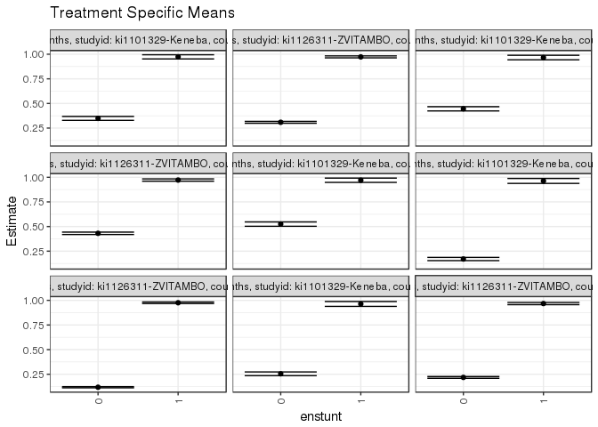

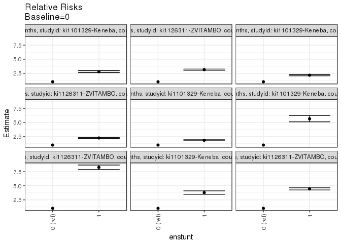

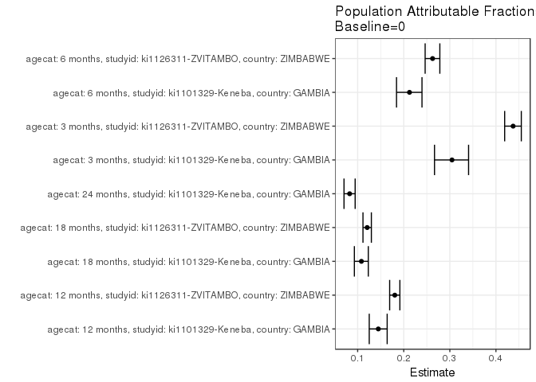

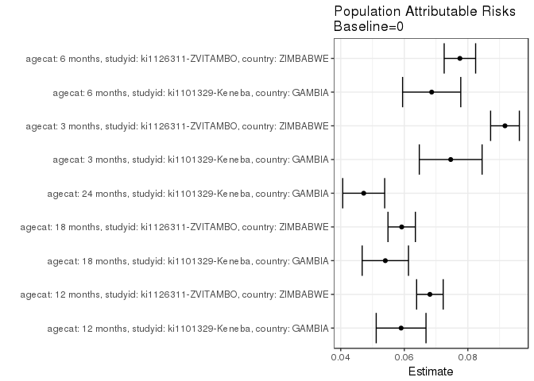

## Results Table

### Parameter: TSM

| agecat | studyid | country | intervention_level | baseline_level | estimate | ci_lower | ci_upper |
| --- | --- | --- | --- | --- | --- | --- | --- |
| 3 months | ki1101329-Keneba | GAMBIA | 0 | NA | 0.1702742 | 0.1541136 | 0.1864348 |
| 3 months | ki1101329-Keneba | GAMBIA | 1 | NA | 0.9629629 | 0.9377723 | 0.9881536 |
| 3 months | ki1126311-ZVITAMBO | ZIMBABWE | 0 | NA | 0.1179929 | 0.1123183 | 0.1236675 |
| 3 months | ki1126311-ZVITAMBO | ZIMBABWE | 1 | NA | 0.9757739 | 0.9679563 | 0.9835914 |
| 6 months | ki1101329-Keneba | GAMBIA | 0 | NA | 0.2544031 | 0.2355181 | 0.2732881 |
| 6 months | ki1101329-Keneba | GAMBIA | 1 | NA | 0.9634703 | 0.9386181 | 0.9883225 |
| 6 months | ki1126311-ZVITAMBO | ZIMBABWE | 0 | NA | 0.2177200 | 0.2087153 | 0.2267246 |
| 6 months | ki1126311-ZVITAMBO | ZIMBABWE | 1 | NA | 0.9677419 | 0.9563858 | 0.9790980 |
| 12 months | ki1101329-Keneba | GAMBIA | 0 | NA | 0.3484708 | 0.3283630 | 0.3685786 |
| 12 months | ki1101329-Keneba | GAMBIA | 1 | NA | 0.9733333 | 0.9522780 | 0.9943887 |
| 12 months | ki1126311-ZVITAMBO | ZIMBABWE | 0 | NA | 0.3088512 | 0.2993198 | 0.3183827 |
| 12 months | ki1126311-ZVITAMBO | ZIMBABWE | 1 | NA | 0.9728419 | 0.9629196 | 0.9827642 |
| 18 months | ki1101329-Keneba | GAMBIA | 0 | NA | 0.4457478 | 0.4242057 | 0.4672899 |
| 18 months | ki1101329-Keneba | GAMBIA | 1 | NA | 0.9662447 | 0.9432470 | 0.9892423 |
| 18 months | ki1126311-ZVITAMBO | ZIMBABWE | 0 | NA | 0.4312256 | 0.4190962 | 0.4433551 |
| 18 months | ki1126311-ZVITAMBO | ZIMBABWE | 1 | NA | 0.9720457 | 0.9605282 | 0.9835632 |
| 24 months | ki1101329-Keneba | GAMBIA | 0 | NA | 0.5248479 | 0.5028021 | 0.5468937 |
| 24 months | ki1101329-Keneba | GAMBIA | 1 | NA | 0.9700855 | 0.9482539 | 0.9919170 |

### Parameter: E(Y)

| agecat | studyid | country | intervention_level | baseline_level | estimate | ci_lower | ci_upper |
| --- | --- | --- | --- | --- | --- | --- | --- |
| 3 months | ki1101329-Keneba | GAMBIA | NA | NA | 0.2448802 | 0.2272833 | 0.2624771 |
| 3 months | ki1126311-ZVITAMBO | ZIMBABWE | NA | NA | 0.2096821 | 0.2029149 | 0.2164492 |
| 6 months | ki1101329-Keneba | GAMBIA | NA | NA | 0.3230225 | 0.3037515 | 0.3422936 |
| 6 months | ki1126311-ZVITAMBO | ZIMBABWE | NA | NA | 0.2952222 | 0.2857979 | 0.3046466 |
| 12 months | ki1101329-Keneba | GAMBIA | NA | NA | 0.4074696 | 0.3877372 | 0.4272020 |
| 12 months | ki1126311-ZVITAMBO | ZIMBABWE | NA | NA | 0.3769139 | 0.3674426 | 0.3863852 |
| 18 months | ki1101329-Keneba | GAMBIA | NA | NA | 0.4997810 | 0.4792665 | 0.5202955 |
| 18 months | ki1126311-ZVITAMBO | ZIMBABWE | NA | NA | 0.4904060 | 0.4788517 | 0.5019603 |
| 24 months | ki1101329-Keneba | GAMBIA | NA | NA | 0.5720762 | 0.5514245 | 0.5927278 |

### Parameter: RR

| agecat | studyid | country | intervention_level | baseline_level | estimate | ci_lower | ci_upper |
| --- | --- | --- | --- | --- | --- | --- | --- |
| 3 months | ki1101329-Keneba | GAMBIA | 0 | 0 | 1.000000 | 1.000000 | 1.000000 |
| 3 months | ki1101329-Keneba | GAMBIA | 1 | 0 | 5.655367 | 5.125134 | 6.240457 |
| 3 months | ki1126311-ZVITAMBO | ZIMBABWE | 0 | 0 | 1.000000 | 1.000000 | 1.000000 |
| 3 months | ki1126311-ZVITAMBO | ZIMBABWE | 1 | 0 | 8.269767 | 7.876240 | 8.682956 |
| 6 months | ki1101329-Keneba | GAMBIA | 0 | 0 | 1.000000 | 1.000000 | 1.000000 |
| 6 months | ki1101329-Keneba | GAMBIA | 1 | 0 | 3.787179 | 3.500953 | 4.096807 |
| 6 months | ki1126311-ZVITAMBO | ZIMBABWE | 0 | 0 | 1.000000 | 1.000000 | 1.000000 |
| 6 months | ki1126311-ZVITAMBO | ZIMBABWE | 1 | 0 | 4.444893 | 4.257851 | 4.640152 |
| 12 months | ki1101329-Keneba | GAMBIA | 0 | 0 | 1.000000 | 1.000000 | 1.000000 |
| 12 months | ki1101329-Keneba | GAMBIA | 1 | 0 | 2.793156 | 2.626226 | 2.970697 |
| 12 months | ki1126311-ZVITAMBO | ZIMBABWE | 0 | 0 | 1.000000 | 1.000000 | 1.000000 |
| 12 months | ki1126311-ZVITAMBO | ZIMBABWE | 1 | 0 | 3.149872 | 3.049139 | 3.253933 |
| 18 months | ki1101329-Keneba | GAMBIA | 0 | 0 | 1.000000 | 1.000000 | 1.000000 |
| 18 months | ki1101329-Keneba | GAMBIA | 1 | 0 | 2.167694 | 2.054007 | 2.287672 |
| 18 months | ki1126311-ZVITAMBO | ZIMBABWE | 0 | 0 | 1.000000 | 1.000000 | 1.000000 |
| 18 months | ki1126311-ZVITAMBO | ZIMBABWE | 1 | 0 | 2.254147 | 2.186386 | 2.324008 |
| 24 months | ki1101329-Keneba | GAMBIA | 0 | 0 | 1.000000 | 1.000000 | 1.000000 |
| 24 months | ki1101329-Keneba | GAMBIA | 1 | 0 | 1.848317 | 1.762305 | 1.938528 |

### Parameter: PAR

| agecat | studyid | country | intervention_level | baseline_level | estimate | ci_lower | ci_upper |
| --- | --- | --- | --- | --- | --- | --- | --- |
| 3 months | ki1101329-Keneba | GAMBIA | 0 | NA | 0.0746060 | 0.0647244 | 0.0844876 |
| 3 months | ki1126311-ZVITAMBO | ZIMBABWE | 0 | NA | 0.0916891 | 0.0871640 | 0.0962143 |
| 6 months | ki1101329-Keneba | GAMBIA | 0 | NA | 0.0686194 | 0.0594675 | 0.0777713 |
| 6 months | ki1126311-ZVITAMBO | ZIMBABWE | 0 | NA | 0.0775023 | 0.0725533 | 0.0824512 |
| 12 months | ki1101329-Keneba | GAMBIA | 0 | NA | 0.0589988 | 0.0511631 | 0.0668344 |
| 12 months | ki1126311-ZVITAMBO | ZIMBABWE | 0 | NA | 0.0680627 | 0.0638815 | 0.0722438 |
| 18 months | ki1101329-Keneba | GAMBIA | 0 | NA | 0.0540332 | 0.0467442 | 0.0613222 |
| 18 months | ki1126311-ZVITAMBO | ZIMBABWE | 0 | NA | 0.0591804 | 0.0548703 | 0.0634905 |
| 24 months | ki1101329-Keneba | GAMBIA | 0 | NA | 0.0472283 | 0.0406268 | 0.0538297 |

### Parameter: PAF

| agecat | studyid | country | intervention_level | baseline_level | estimate | ci_lower | ci_upper |
| --- | --- | --- | --- | --- | --- | --- | --- |
| 3 months | ki1101329-Keneba | GAMBIA | 0 | NA | 0.3046633 | 0.2667151 | 0.3406476 |
| 3 months | ki1126311-ZVITAMBO | ZIMBABWE | 0 | NA | 0.4372770 | 0.4189272 | 0.4550473 |
| 6 months | ki1101329-Keneba | GAMBIA | 0 | NA | 0.2124292 | 0.1843201 | 0.2395696 |
| 6 months | ki1126311-ZVITAMBO | ZIMBABWE | 0 | NA | 0.2625218 | 0.2464053 | 0.2782936 |
| 12 months | ki1101329-Keneba | GAMBIA | 0 | NA | 0.1447931 | 0.1251162 | 0.1640274 |
| 12 months | ki1126311-ZVITAMBO | ZIMBABWE | 0 | NA | 0.1805788 | 0.1694185 | 0.1915892 |
| 18 months | ki1101329-Keneba | GAMBIA | 0 | NA | 0.1081137 | 0.0928819 | 0.1230898 |
| 18 months | ki1126311-ZVITAMBO | ZIMBABWE | 0 | NA | 0.1206763 | 0.1115274 | 0.1297311 |
| 24 months | ki1101329-Keneba | GAMBIA | 0 | NA | 0.0825559 | 0.0703903 | 0.0945624 |